# Project-7

Hannes Gubler

28 May, 2023

# 1 Introduction

In this report, the goal is to assist and explain a clinical dietitian how to determine the required sample size for her experiment. The request is the following.

*A clinical dietitian wants to compare two different diets, A and B, for diabetic patients. She hypothesizes that diet A (Group 1) will be better than diet B (Group 2), in terms of lower blood glucose. She plans to get a random sample of diabetic patients and randomly assign them to one of the two diets. At the end of the experiment, which lasts 6 weeks, a fasting blood glucose test will be conducted on each patient. She also expects that the average difference in blood glucose measure between the two groups will be about 10 mg/dl. The dietitian wants to know the number of subjects needed in each group assuming equal sized groups.*

The hypothesis of the dietitian can be formulated as follows (to statistically test whether diet A is better than diet B).

- $H_0$ (Null Hypothesis): There is no difference in blood glucose level between group A and group B.
- $H_1$ (Alternative Hypothesis): Diet A will be better than diet B (in terms of lower blood glucose).

Our statistical test will either reject $H_0$ (and therefore conclude $H_1$) or not reject $H_0$. So if we want to conclude that diet A is better than diet B, we want to reject $H_0$.

# 2 Technical Terms

To statistically test the Null Hypothesis vs the Alternative Hypothesis ($H_0$ vs $H_1$) we need to specify the *significance level*. The significance level is used to determine how strong the evidence against $H_0$ needs to be in order to reject the Null Hypothesis $H_0$ and therefore conclude the Alternative Hypothesis $H_1$. It represents the probability of rejecting $H_0$ when it is actually true. If we decrease the significance level, it becomes more difficult to reject $H_0$. Clinical dietitians usually consider a significance level of 5%, therefore we set our significance level to 5%.

In order to calculate the number of subjects needed, we also need to specify the desired *power level* of the test. The power level is the probability of correctly rejecting the Null Hypothesis $H_0$ when $H_1$ is true. In other words, it measures the ability of our statistical test to detect a lower blood glucose in group 1 than in group 2. We choose our power level to be 80% (a usual value for clinical dietitians), which means that if group 1 has a lower blood glucose than group 2, we have an 80% chance of correctly detecting it.

# 3 Statistical Test

To statistically test $H_0$ vs $H_1$, we use the so called *two sample t-test*, which is the usual test to determine whether two population means are equal or not. When applying the two sample t-test to our data, we have the following assumptions (that need to be satisfied in order for our test to work).

1. The observations (subjects) from group 1 should be independent to the observations from group 2.
2. The blood glucose level of observations from group 1 should have approximately the same *standard deviation* as in group 2. The standard deviation in a group describes how spread out the set of blood glucose numbers from its subjects is. In our case, we assume the standard deviation in both groups to be 15 mg/dl (a typical value for the standard deviation in blood glucose).
3. The individuals have been assigned randomly to either group 1 or group 2.

The fourth assumption is a little bit more technical: We assume that the data is approximately *normal distributed*. It refers to a specific shape of the data when we plot it on a graph. If the data is normal distributed, most of the datapoints are concentrated around the middle. It turns out that many different kinds of data are normal distributed.

So when we take the significance level 0.05, a power level of 80% and a standard deviation of 15 mg/dl, we calculate that we need 29 subjects in each group (group 1 and group 2) for our test.

Note that however if we change the standard deviation of the blood glucose, our result will change. As a higher standard deviation means that the blood glucose levels are more spread out, we need a larger number of subjects to determine a difference in means in our groups, provided we keep the same significance level and power level.

The same goes for the significance level. If we want to lower the significance level (the probability of rejecting the Null Hypothesis $H_0$ when it is actually true), we need more subjects provided we keep the same power level and standard deviation.

Similarly, if we want to use a higher power level (the probability of correctly rejecting the Null Hypothesis $H_0$ when $H_1$ is true), we need more subjects provided we keep the same significance level and standard deviation.

Due to the above effects, in Figure (3.1) we compare different scenarios of standard deviations, significant levels and power levels.

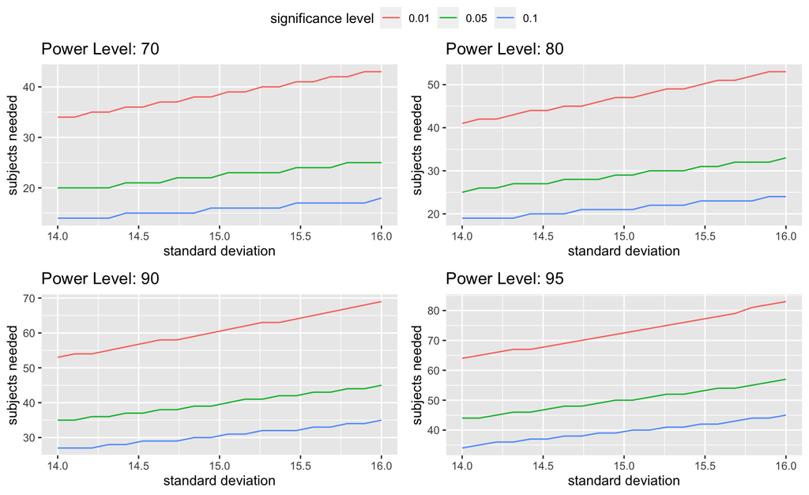

Figure 3.1: Number of subjects needed per group (y-axis) in scenarios of different standard deviations, power levels and significance levels.

# 4 Conclusion

In this report we showed that, when using a typical standard deviation in the blood glucose levels of 15 mg/dl, and the by clinical dietitians widely used significance level of 5% and power level of 80%, we need 29 subjects per group to test the Null Hypothesis $H_0$ vs the Alternative Hypothesis $H_1$. However if we change those commonly used values for standard deviation, significance level and power level, the number of subjects needed per group changes as seen in Figure (3.1).